# ZFS

## Транзакционные группы (TXG)

В ZFS присутствует концепция транзакционной записи данных. Транзакционность предоставляет возможность "атомарной" записи блоков данных: в случае возникновения ошибок при записи, все новые данные будут отброшены. Также это позволяет объединять запись нескольких блоков в одну операцию, что добавляет некоторую последовательность записи (sequential writings), которая увеличивает быстродействие. Кроме того, номера транзакционных групп могут использоваться для определения "возраста" блоков при "лечении", импорте или отправке пула.

Для увеличения производительности запись производится в рамках транзакционных групп (`txg`). Обычно транзакционная группа ассоциируется с некоторым числом (номером транзакционной группы).

Рассмотрим вначале состояния, в которых может пребывать `TXG` (всего их 3, задаётся макросом `TXG_CONCURRENT_STATES`):

1. Opening - транзакционная группа "открыта" для добавления новых транзакций.
2. Quiescsing - освобождаются все блокировки, которыми захватываются транзакции в группе, группа переходит в состояние "стабилизации".
3. Syncing - после стабилизации группа переходит в состояние синхронизации - записи данных на диск.

Как было замечено, транзакционные группы идентифицируются при помощи номеров (типа `uint64_t`). Структуры, хранящие данные групп имеют размер, равный 4 (`TXG_SIZE`, следующая после `TXG_CONCURRENT_STATES` степень двойки). Таким образом, есть 4 состояния:

- открытое;
- стабилизированное;
- синхронизирующееся;
- синхронизированное;

Благодаря битовой маске, равной 3 (`TXG_MASK = TXG_SIZE - 1`) и инкрементации номера транзакций, эти структуры образуют подобие кольцевого буфера.

Один из авторов ZFS утверждал, что можно было обойтись без состояния "стабилизации", однако это повлекло бы за собой переписывание большого объёма кода.

Рассмотрим использование данного механизма на примере функции `zvol_write` (`zvol.c`). Данная функция вызвывается в случае, если блочному устройству `zvol` пришёл запрос на запись. Функция принимает в качестве аргумента структуру тип `bio` (`<linux-src>/include/linux/blk-types.h`), которая содержит в себе флаги (запись/чтение, сброс), "приватные" данные блочного устройства, смещение и размер данных, и буфер для данных.

```c
static int zvol_write(struct bio *bio)
{
    zvol_state_t *zv = bio->bi_bdev->bd_disk->private_data;
    uint64_t offset = BIO_BI_SECTOR(bio) << 9;
    uint64_t size = BIO_BI_SIZE(bio);
    int error = 0;
    dmu_tx_t *tx;
    rl_t *rl;
```

Вначале, если есть необходимость, происходит сброс данных в `ZIL`. Если в запросе отсутствуют данные на запись, то функция завершает свою работу.

```c
//zvol_write
    if (bio->bi_rw & VDEV_REQ_FLUSH)
        zil_commit(zv->zv_zilog, ZVOL_OBJ);

    if (size == 0)
        goto out;
```

Если данные для записи присутствуют, то начинается их запись. Получаем блокировку на запись для области `[offset, offset + size]`. Эта блокировка работает только на уровне `zvol`:

```c
//zvol_write
    rl = zfs_range_lock(&zv->zv_znode, offset, size, RL_WRITER);
```

Следующий шаг - создание транзакции:

```c
//zvol_write
    tx = dmu_tx_create(zv->zv_objset);
```

Рассмотрим код этой функции. Вначале аллоцируется и инициализируется транзакционная группа, привязанная к `DSL Directory` датасета. При инициализации создаётся список блокировок (`tx->tx_holds`) который в дальнейшем будет использоваться для добавления данных в транзакционную группу. Затем в `tx` устанавливается значение `tx->tx_objset` и значение номера транзакционной группы, в которой производилась запись последнего снапшота (или имела место неудачная попытка записи этого снапшота).

```c
dmu_tx_t * dmu_tx_create(objset_t *os)
{
    dmu_tx_t *tx = dmu_tx_create_dd(os->os_dsl_dataset->ds_dir);
    tx->tx_objset = os;
    tx->tx_lastsnap_txg = dsl_dataset_prev_snap_txg(os->os_dsl_dataset);
    return (tx);
}
```

После создания транзакционной группы необходимо произвести захват пространства `[offset, offset + size]` в объекте `ZVOL_OBJ`. Захват позволяет добавить необходимые данные в транзакционную группу `tx`.

```c
//zvol_write
    dmu_tx_hold_write(tx, ZVOL_OBJ, offset, size);
```

Рассмотрим подробнее:

```c
void dmu_tx_hold_write(dmu_tx_t *tx, uint64_t object, uint64_t off, int len)
{
    dmu_tx_hold_t *txh;
    txh = dmu_tx_hold_object_impl(tx, tx->tx_objset, object, THT_WRITE, off, len);
    if (txh == NULL)
        return;
    dmu_tx_count_write(txh, off, len);
    dmu_tx_count_dnode(txh);
}
```

В функцию `dmu_tx_hold_object_impl` передаётся новый аргумент - тип захвата (`dmu_tx_hold_type`). В данном случае это `THT_WRITE`. Он используется в отладочных целях. Рассмотрим упрощённый код данной функции:

```c
static dmu_tx_hold_t *
dmu_tx_hold_object_impl(dmu_tx_t *tx, objset, object) {
    dnode_t dnode = NULL;
    if is exists(object)
    {
        dnode = dnode_hold(objset, object, tx);
        lock(dnode->dn_mtx);
        dnode->assigned_txg = tx->txg;
        addref to dnode->dn_tx_holds by tx;
        unlock(dnode->dn_mtx)
    }
    dmu_tx_hold_t txh = alloc();
    txh->tx = tx;
    tx->dnode = dnode;
    list_insert_tail(tx->holds, txh);
    return txh;
}
```

Из кода видно, что если объект (`dnode`) уже существует, то его необходимо захватить и присвоить ему соответствующую транзакционную группу. Потом необходимо создать объект, который будет удерживать этот захват (`dmu_tx_hold_t`) и добавить этот объект в список захватов данной группы (`tx->holds`).

Функция `dnode_hold` вызывает функцию `dnode_hold_impl`, которая захватывает `object` в `objset` и возвращает `dnode_t`, которая ему соответствует. При захвате `dnode` вначале считывается с диска `dnode_phys` из `MetaNode` (мета-объекта), а затем добавляются захваты в `MetaNode` и в саму `dnode`.

Вернёмся назад по стеку функций. Вызов `dmu_tx_hold_object_impl` возвращает объект, который удерживает захват группы. Данный объект и значения `(offset, size)` передаются в функцию `dmu_tx_count_write`. Ещё задача - определить количество данных, которое будет записано.

Этапы выполнения этой функции:

1. Проверка (посредством чтения) первого и последнего блоков на уровне 0 и проверка всех блоков первого уровня.
2. Определение максимального/минимального размера блока (`min_bs, max_bs`) и размера косвенного блока (`min_ibs = max_ibs = dn->dn_indblkshift`);

Функция `dmu_tx_count_dnode` подобна функции `dmu_tx_count_write`, однако она определяет количество данных, которое будет записано в самой `dnode`.

Итак, мы создали транзакцию и захватили её. Теперь необходимо присвоить её транзакционной группе. Для этого вызываем функцию `dmu_tx_assign`:

```c
// zvol_write
    error = dmu_tx_assign(tx, TXG_WAIT);
    if (error) {
        dmu_tx_abort(tx);
        zfs_range_unlock(rl);
        goto out;
    }
```

1. `TXG_WAIT` - если текущая открытая группа заполнена, то ожидать новую.
2. `TXG_NOWAIT` - неблокирующий вызов. В случае, если открытая группа заполнена, будет возвращено управление и код `ERESTART`.
3. `TXG_WAITED` - как TXG_NOWAIT, но указывает на то, что `dmu_tx_wait` уже вызвана от имени этой операции (хотя скорее всего на другой транзакции).

```c
int dmu_tx_assign(dmu_tx_t *tx)
{
    int err;
    while ((err = dmu_tx_try_assign(tx, TXG_WAIT)) != 0) {
        dmu_tx_unassign(tx);
        if (err != ERESTART)
            return (err);
        dmu_tx_wait(tx);
    }

    txg_rele_to_quiesce(&tx->tx_txgh);
    return (0);
}
```

Рассмотрим код функции `dmu_tx_try_assign`:

```c
static int
dmu_tx_try_assign(dmu_tx_t *tx, txg_how_t txg_how)
{
    dmu_tx_hold_t *txh;
    spa_t *spa = tx->tx_pool->dp_spa;
    uint64_t memory, asize, fsize, usize;
    uint64_t towrite, tofree, tooverwrite, tounref, tohold, fudge;
```

Вначале мы проверяем, нужна ли задержка для заполнения транзакционной группы (см. раздел "Задержка транзакций"):

```c
// dmu_tx_try_assign
    if (!tx->tx_waited && dsl_pool_need_dirty_delay(tx->tx_pool)) {
        tx->tx_wait_dirty = B_TRUE;
        return (ERESTART);
    }
```

Если мы попали сюда, то значит, что ждать новые транзакции нам не нужно. Производим захват транзакционной группы (см. раздел "Особенности реализации транзакционных групп").

```c
// dmu_tx_try_assign
    tx->tx_txg = txg_hold_open(tx->tx_pool, &tx->tx_txgh);
    tx->tx_needassign_txh = NULL;
```

Затем проходим по всему списку объектов, которые удерживаются данной транзакцией.

Если объекту была назначена предыдущая транзакция, то его необходимо переназначить на текущую. Уходим с кодом `ERESTART`.

Если объекту не была назначена транзакция, то сразу назначаем ему текущую.

Увеличиваем счётчик владения объектом (объект используется данной транзакцией).

Затем увеличиваем счётчики количества записанных/освобождённых данных.

```c
// dmu_tx_try_assign
    towrite = tofree = tooverwrite = tounref = tohold = fudge = 0;
    for (txh = list_head(&tx->tx_holds); txh; txh = list_next(&tx->tx_holds, txh)) {
        dnode_t *dn = txh->txh_dnode;
        if (dn != NULL) {
            mutex_enter(&dn->dn_mtx);
            if (dn->dn_assigned_txg == tx->tx_txg - 1) {
                mutex_exit(&dn->dn_mtx);
                tx->tx_needassign_txh = txh;
                DMU_TX_STAT_BUMP(dmu_tx_group);
                return (SET_ERROR(ERESTART));
            }
            if (dn->dn_assigned_txg == 0)
                dn->dn_assigned_txg = tx->tx_txg;
            refcount_add(&dn->dn_tx_holds, tx);
            mutex_exit(&dn->dn_mtx);
        }
        towrite += txh->txh_space_towrite;
        tofree += txh->txh_space_tofree;
        tooverwrite += txh->txh_space_tooverwrite;
        tounref += txh->txh_space_tounref;
        tohold += txh->txh_memory_tohold;
        fudge += txh->txh_fudge;
    }
```

Если после того, как мы определили счётчики `towrite, tofree, etc`, был сделан снапшот, то мы не сможем ничего перезаписать или освободить:

```c
// dmu_tx_try_assign
    if (tx->tx_objset &&
        dsl_dataset_prev_snap_txg(tx->tx_objset->os_dsl_dataset) >
        tx->tx_lastsnap_txg) {
        towrite += tooverwrite;
        tooverwrite = tofree = 0;
    }
```

Учтём наихудший вариант событий:

Максимальной четности `RAID-Z` блоки размером в один сектор (`ashift`), в этом случае требуется в `(VDEV_RAIDZ_MAXPARITY + 1)` раз больше места. Добавим к этому тот факт, что мы можем иметь до 3 `DVA` на один `BP`, а ещё умножим на 2, потому что блок может быть дублирован до 3 `DVA` в `ddt_sync`. Таким образом получим дефолтное значение параметра модуля `spa_asize_inflation`:

```c
spa_asize_inflation = (VDEV_RAIDZ_MAXPARITY + 1) * SPA_DVAS_PER_BP * 2 = 24
```

Функция `spa_get_asize` производит умножение этого коэффициента на входной аргумент и отдаёт результат. Таким образом, мы получаем самые "худшие" значения параметров:

```c
// dmu_tx_try_assign
    /* needed allocation: worst-case estimate of write space */
    asize = spa_get_asize(tx->tx_pool->dp_spa, towrite + tooverwrite);
    /* freed space estimate: worst-case overwrite + free estimate */
    fsize = spa_get_asize(tx->tx_pool->dp_spa, tooverwrite) + tofree;
    /* convert unrefd space to worst-case estimate */
    usize = spa_get_asize(tx->tx_pool->dp_spa, tounref);
    /* calculate memory footprint estimate */
    memory = towrite + tooverwrite + tohold;
```

Теперь необходимо запросить у `DSL Directory` датасета, сможет ли он выделить необходимое количество ресурсов, и в случае успеха можно переходить к следующему этапу.

```c
// dmu_tx_try_assign
    if (tx->tx_dir && asize != 0) {
        int err = dsl_dir_tempreserve_space(tx->tx_dir, memory,
            asize, fsize, usize, &tx->tx_tempreserve_cookie, tx);
        if (err)
            return (err);
    }

    return (0);
}
```

В случае неудачи, например, потому что группа заполнена (или другая причина, по которой был возвращён код `ERESTART`), в цикле функции `dmu_tx_assign` будет выполнены `dmu_tx_unassign` и `dmu_tx_wait`.

Рассмотрим `dmu_tx_unassign`. Освобождаем "захват" открытой транзакции и очищаем присвоенные объектам (`dnode`) номера транзакций, затем освобождаем транзакцию.

```c
static void dmu_tx_unassign(dmu_tx_t *tx)
{
    dmu_tx_hold_t *txh;

    if (tx->tx_txg == 0)
        return;
```

Вначале освободим блокировки в дескрипторе открытой транзакционной группы:

```c
    txg_rele_to_quiesce(&tx->tx_txgh);
```

Затем пройдёмся по всему списку "захвата", проведём освобождение каждого объекта (`dnode`), который с ним ассоциирован и уведомим об этом ожидающих, сбрасывая `refcount` в 0.

```c
    for (txh = list_head(&tx->tx_holds); txh != tx->tx_needassign_txh;
        txh = list_next(&tx->tx_holds, txh)) {
        dnode_t *dn = txh->txh_dnode;

        if (dn == NULL)
            continue;
        mutex_enter(&dn->dn_mtx);
        ASSERT3U(dn->dn_assigned_txg, ==, tx->tx_txg);

        if (refcount_remove(&dn->dn_tx_holds, tx) == 0) {
            dn->dn_assigned_txg = 0;
            cv_broadcast(&dn->dn_notxholds);
        }
        mutex_exit(&dn->dn_mtx);
    }
```

После этого можно освободить сам дескриптор:

```
    txg_rele_to_sync(&tx->tx_txgh);

    tx->tx_lasttried_txg = tx->tx_txg;
    tx->tx_txg = 0;
}
```

Теперь перейдём к функции `dmu_tx_wait`:

```c
void dmu_tx_wait(dmu_tx_t *tx)
{
    spa_t *spa = tx->tx_pool->dp_spa;
    dsl_pool_t *dp = tx->tx_pool;
    hrtime_t before;

    before = gethrtime();
```

Теперь, если нам необходимо подождать, пока не придут новые данные (т.е. дождаться, когда заполнится транзакционная группа):

```c
// dmu_tx_wait
    if (tx->tx_wait_dirty) {
        uint64_t dirty;
        mutex_enter(&dp->dp_lock);
        if (dp->dp_dirty_total >= zfs_dirty_data_max)
            DMU_TX_STAT_BUMP(dmu_tx_dirty_over_max);
        while (dp->dp_dirty_total >= zfs_dirty_data_max)
            cv_wait(&dp->dp_spaceavail_cv, &dp->dp_lock);
        dirty = dp->dp_dirty_total;
        mutex_exit(&dp->dp_lock);

        dmu_tx_delay(tx, dirty);

        tx->tx_wait_dirty = B_FALSE;
        tx->tx_waited = B_TRUE;
```

Иначе, если пул приостановлен или мы ещё не пытались добавить транзакцию в группу, то дождёмся завершится синхронизация:

```c
// dmu_tx_wait
    } else if (spa_suspended(spa) || tx->tx_lasttried_txg == 0) {
        /*
         * If the pool is suspended we need to wait until it
         * is resumed.  Note that it's possible that the pool
         * has become active after this thread has tried to
         * obtain a tx.  If that's the case then tx_lasttried_txg
         * would not have been set.
         */
        txg_wait_synced(dp, spa_last_synced_txg(spa) + 1);
```

Если в `dmu_tx_try_assign` было установлено, что имела место попытка добавить данную `dnode` в предыдущую группу, и она не добавилась (`dnode`), то дожидаемся особождения захватов, связанных с этим объектом.

```c
// dmu_tx_wait
    } else if (tx->tx_needassign_txh) {
        dnode_t *dn = tx->tx_needassign_txh->txh_dnode;

        mutex_enter(&dn->dn_mtx);
        while (dn->dn_assigned_txg == tx->tx_lasttried_txg - 1)
            cv_wait(&dn->dn_notxholds, &dn->dn_mtx);
        mutex_exit(&dn->dn_mtx);
        tx->tx_needassign_txh = NULL;
```

Иначе - `dnode` уже находится в "стабилизирующейся" группе. Просто дождёмся пока данная группа стабилизируется.

```c
// dmu_tx_wait
    } else {
        /*
         * A dnode is assigned to the quiescing txg.  Wait for its
         * transaction to complete.
         */
        txg_wait_open(tx->tx_pool, tx->tx_lasttried_txg + 1);
    }
```

Добавляем затраченное время в статистику. В файле `/proc/spl/<pool-name>/dmu_tx_assign` хранится гистограмма, показывающая распределение времени ожидания добавления транзакций в группы.

```c
// dmu_tx_wait
    spa_tx_assign_add_nsecs(spa, gethrtime() - before);
}
```

Итак, нам удалось добавить транзакцию в группу. Теперь транзакция `tx` принадлежит открытой группу транзакций, держа соответствующие `hold`'ы. На следующем этапе нам необходимо записать данные `bio` в объект `ZVOL` в рамках транзакции `tx`.

```c
// zvol_write
    error = dmu_write_bio(zv->zv_objset, ZVOL_OBJ, bio, tx);
```

Рассмотрим подробнее эту функцию:

```c
dmu_write_bio(objset_t *os, uint64_t object, struct bio *bio, dmu_tx_t *tx)
{
    uint64_t offset = BIO_BI_SECTOR(bio) << 9;
    uint64_t size = BIO_BI_SIZE(bio);
    dmu_buf_t **dbp;
    int numbufs, i, err;
    size_t bio_offset;

    if (size == 0)
        return (0);
```

Инициируем чтение блока данных `[offset, offset + size]` и их захват в буферы системы `DMU` (`DBUF`).

```c
// dmu_write_bio
    err = dmu_buf_hold_array(os, object, offset, size, FALSE, FTAG,
        &numbufs, &dbp);
    if (err)
        return (err);
```

В функции `dmu_buf_hold_array` захватывается вначале объект (`dnode`), а потом - блок данных этого объекта:

```c
static int dmu_buf_hold_array(objset_t *os, uint64_t object, uint64_t offset,
    uint64_t length, int read, void *tag, int *numbufsp, dmu_buf_t ***dbpp)
{
    dnode_t *dn;
    int err;

    err = dnode_hold(os, object, FTAG, &dn);
    if (err)
        return (err);

    err = dmu_buf_hold_array_by_dnode(dn, offset, length, read, tag,
        numbufsp, dbpp, DMU_READ_PREFETCH);

    dnode_rele(dn, FTAG);

    return (err);
}
```

Рассмотрим `dmu_buf_hold_array_by_dnode`:

```c
int dmu_buf_hold_array_by_dnode(dnode_t *dn, uint64_t offset, uint64_t length,
    int read, void *tag, int *numbufsp, dmu_buf_t ***dbpp, uint32_t flags)
{
    dmu_buf_t **dbp;
    uint64_t blkid, nblks, i;
    uint32_t dbuf_flags;
    int err;
    zio_t *zio;

    dbuf_flags = DB_RF_CANFAIL | DB_RF_NEVERWAIT | DB_RF_HAVESTRUCT;
    if (flags & DMU_READ_NO_PREFETCH || length > zfetch_array_rd_sz)
        dbuf_flags |= DB_RF_NOPREFETCH;

    rw_enter(&dn->dn_struct_rwlock, RW_READER);
```

Вычисляем количество блоков (равное количеству буферов), которые нам необходимо захватить и аллоцируем такое же количество буферов:

```c
// dmu_buf_hold_array_by_dnode
    if (dn->dn_datablkshift) {
        int blkshift = dn->dn_datablkshift;
        nblks = (P2ROUNDUP(offset+length, 1ULL<<blkshift) -
            P2ALIGN(offset, 1ULL<<blkshift)) >> blkshift;
    } else {
        if (offset + length > dn->dn_datablksz) {
            // zfs_panic_recover(...)
            rw_exit(&dn->dn_struct_rwlock);
            return (SET_ERROR(EIO));
        }
        nblks = 1;
    }
    dbp = kmem_zalloc(sizeof (dmu_buf_t *) * nblks, KM_SLEEP);
```

Создаём ZIO-объект, который будет родителем для запросов на чтение блоков данных.

Затем получаем индекс косвенного блока, по адресу `offset`, равный *o**f**f**s**e**t*/(2<sup>*d**n*_*d**a**t**a**b**l**k**s**h**i**f**t*</sup>) при помощи `dbuf_whichblock`.

Затем проходим по всем блокам и захватываем их. Захват блока выполняет рекурсивный поиск, доходя до `L0`-блоков. В процессе выполнения этой функции из ARC считываются косвенные блоки при помощи функции `dbuf_read`. Подробности работы этой функции (`dbuf_hold`) изложены в разделе "DBUF/Реализация COW-механизма в DBUF"

```c
// dmu_buf_hold_array_by_dnode
    zio = zio_root(dn->dn_objset->os_spa, NULL, NULL, ZIO_FLAG_CANFAIL);
    blkid = dbuf_whichblock(dn, offset);
    for (i = 0; i < nblks; i++) {
        dmu_buf_impl_t *db = dbuf_hold(dn, blkid+i, tag);
        if (db == NULL) {
            rw_exit(&dn->dn_struct_rwlock);
            dmu_buf_rele_array(dbp, nblks, tag);
            zio_nowait(zio);
            return (SET_ERROR(EIO));
        }
        /* initiate async i/o */
        if (read) {
            (void) dbuf_read(db, zio, dbuf_flags);
        }
        dbp[i] = &db->db;
    }
    rw_exit(&dn->dn_struct_rwlock);
```

Запускаем ZIO-конвейер:

```c
    err = zio_wait(zio);
    if (err) {
        dmu_buf_rele_array(dbp, nblks, tag);
        return (err);
    }
```

```c
    /* wait for other io to complete */
    if (read) {
        for (i = 0; i < nblks; i++) {
            dmu_buf_impl_t *db = (dmu_buf_impl_t *)dbp[i];
            mutex_enter(&db->db_mtx);
            while (db->db_state == DB_READ ||
                db->db_state == DB_FILL)
                cv_wait(&db->db_changed, &db->db_mtx);
            if (db->db_state == DB_UNCACHED)
                err = SET_ERROR(EIO);
            mutex_exit(&db->db_mtx);
            if (err) {
                dmu_buf_rele_array(dbp, nblks, tag);
                return (err);
            }
        }
    }
```

И возвращаем полученный массив объектов `dbuf`:

```c
    *numbufsp = nblks;
    *dbpp = dbp;
    return (0);
}
```

Вернёмся к функции `dmu_write_bio`. После захвата буферов с данными (блоками данных) нам необходимо записать в них значения из `bio`.

Обратите внимание, что в случае, если размер блока данных, предназначенных для копирования равен размеру буфера, то старые данные не будут прочитаны с диска/кэша, т.к. они не нужны - блок данных будет перезаписан (точнее записан в новом месте - не забываем о COW) полностью. Если же буфер перезаписывается не полностью, то нам необходимо записать остатки старых данных в новое место.

После чтения/заполнения буфера, он будет помечен как "грязный" (`dbuf_dirty`) - подлежащий сбросу на диск.

```c
// dmu_write_bio
    bio_offset = 0;
    for (i = 0; i < numbufs; i++) {
        uint64_t tocpy;
        int64_t bufoff;
        int didcpy;
        dmu_buf_t *db = dbp[i];

        bufoff = offset - db->db_offset;
        ASSERT3S(bufoff, >=, 0);

        tocpy = MIN(db->db_size - bufoff, size);
        if (tocpy == 0)
            break;

        ASSERT(i == 0 || i == numbufs-1 || tocpy == db->db_size);

        if (tocpy == db->db_size)
            dmu_buf_will_fill(db, tx);
        else
            dmu_buf_will_dirty(db, tx);

        didcpy = dmu_bio_copy(db->db_data + bufoff, tocpy, bio,
            bio_offset);

        if (tocpy == db->db_size)
            dmu_buf_fill_done(db, tx);

        if (didcpy < tocpy)
            err = EIO;

        if (err)
            break;

        size -= tocpy;
        offset += didcpy;
        bio_offset += didcpy;
        err = 0;
    }

    dmu_buf_rele_array(dbp, numbufs, FTAG);
    return (err);
}
```

Вернёмся к `zvol_write`. После записи данных из `bio` необходимо сделать коммит изменений. Это делается при помощи функции `dmu_tx_commit`. Она освобождает захваченные объекты списках захвата и блокировки синхронизации, позволяя транзакционной группе перейти в стадию синхронизации.

Затем разблокируется область диска и, в случае необходимости (если установлен флаг "forced unit access" - синхронный сброс данных) вызывает запись изменений в ZIL.

```c
// zvol_write
    dmu_tx_commit(tx);
    zfs_range_unlock(rl);

    if ((bio->bi_rw & VDEV_REQ_FUA) ||
        zv->zv_objset->os_sync == ZFS_SYNC_ALWAYS)
        zil_commit(zv->zv_zilog, ZVOL_OBJ);

out:
    return (error);
}
```

### Особенности реализаций транзакционных групп

TODO: описать per-cpu структуру транзакционной группы и почему была выбранна именно такая архитектура.

### Задержки транзакций (ZFS transaction delay)

NB: данный раздел присутствует в man'е к параметрам модуля zfs. Также сюда можно добавить описание работы функции `dsl_pool_need_dirty_delay`.

We delay transactions when we've determined that the backend storage isn't able to accommodate the rate of incoming writes.

If there is already a transaction waiting, we delay relative to when that transaction will finish waiting. This way the calculated delay time is independent of the number of threads concurrently executing transactions.

If we are the only waiter, wait relative to when the transaction started, rather than the current time. This credits the transaction for "time already served", e.g. reading indirect blocks.

The minimum time for a transaction to take is calculated as:

```
   min_time = zfs_delay_scale * (dirty - min) / (max - dirty)
   min_time is then capped at 100 milliseconds.
```

The delay has two degrees of freedom that can be adjusted via tunables. The percentage of dirty data at which we start to delay is defined by zfs_delay_min_dirty_percent. This should typically be at or above zfs_vdev_async_write_active_max_dirty_percent so that we only start to delay after writing at full speed has failed to keep up with the incoming write rate. The scale of the curve is defined by zfs_delay_scale. Roughly speaking, this variable determines the amount of delay at the midpoint of the curve.

```
delay
 10ms +-------------------------------------------------------------*+
      |                                                             *|
  9ms +                                                             *+
      |                                                             *|
  8ms +                                                             *+
      |                                                            * |
  7ms +                                                            * +
      |                                                            * |
  6ms +                                                            * +
      |                                                            * |
  5ms +                                                           *  +
      |                                                           *  |
  4ms +                                                           *  +
      |                                                           *  |
  3ms +                                                          *   +
      |                                                          *   |
  2ms +                                              (midpoint) *    +
      |                                                  |    **     |
  1ms +                                                  v ***       +
      |             zfs_delay_scale ---------->     ********         |
    0 +-------------------------------------*********----------------+
      0%                    <- zfs_dirty_data_max ->               100%
```

Note that since the delay is added to the outstanding time remaining on the most recent transaction, the delay is effectively the inverse of IOPS. Here the midpoint of 500us translates to 2000 IOPS. The shape of the curve was chosen such that small changes in the amount of accumulated dirty data in the first 3/4 of the curve yield relatively small differences in the amount of delay.

The effects can be easier to understand when the amount of delay is represented on a log scale:

```
delay
100ms +-------------------------------------------------------------++
      +                                                              +
      |                                                              |
      +                                                             *+
 10ms +                                                             *+
      +                                                           ** +
      |                                              (midpoint)  **  |
      +                                                  |     **    +
  1ms +                                                  v ****      +
      +             zfs_delay_scale ---------->        *****         +
      |                                             ****             |
      +                                          ****                +
100us +                                        **                    +
      +                                       *                      +
      |                                      *                       |
      +                                     *                        +
 10us +                                     *                        +
      +                                                              +
      |                                                              |
      +                                                              +
      +--------------------------------------------------------------+
      0%                    <- zfs_dirty_data_max ->               100%
```

Note here that only as the amount of dirty data approaches its limit does the delay start to increase rapidly. The goal of a properly tuned system should be to keep the amount of dirty data out of that range by first ensuring that the appropriate limits are set for the I/O scheduler to reach optimal throughput on the backend storage, and then by changing the value of zfs_delay_scale to increase the steepness of the curve.

## SPA

SPA (Storage Pool Allocator) - подсистема, отвечающая за низкоуровневую работу с пулом. Она решает следующие вопросы:

- выделение места под новые блоки (с использованием концепции метаслабов);
- синхронизация пула (запись транзакционных групп);
- управление виртуальными устройствами - (дерево vdev);

### Метаслабы

Причины использования метаслабов для манипуляции с пространством пула описаны в соответствующем разделе space maps.

Каждый vdev (дочерний) разбивается на ~200 областей/элементов, называемых метаслабами. Эти метаслабы образуют "группу метаслабов". Кроме того, каждая группа метаслабов принадлежит некоторому "классу метаслабов". В данный момент подобная "гибкость" не используется (один класс, одинаковые группы для всех vdev'ов), однако заложена возможность задавать отдельные виды групп метаслабов для SLOG-устройств.

Рассмотрим элементы метаслаба, указанные в таблице 2.

Table 2. Элементы метаслаба

| Элемент метаслаба | Операция/назначение | Размер массива | Упорядоченность |
| --- | --- | --- | --- |
| alloc_tree | выделение места | TXG_SIZE = 4 | границы сегмента |
| free_tree | освобождение места | TXG_SIZE = 4 | границы сегмента |
| defer_tree | отложенное освобождение | TXG_DEFER_TREE = 2 | границы сегмента |
| ms_tree | текущее состояние, | 1 | границы сегмента |
| size_tree | дублирует `ms_tree` | 1 | размер сегмента |
| ms_lbas | массив курсоров на LBA | MAX_LBAS = 64 | - |

Каждый метаслаб управляет набором активных деревьев для отслеживания операций над ним. Активное `free tree` (`ms_tree`) содержит текущий список свободных сегментов. Когда блоки выделяются, выделенный под них сегмент удаляется из `ms_tree` и добавляется в `allocation tree` (`ms_alloctree`, см. рис. 5) в соответствии транзакционной группой, в рамках которой происходило выделение сегмента. Когда блоки освобождаются, они добавляются в `free tree` (`ms_freetree`) в соответствии транзакционной группой, в рамках которой происходило освобождение сегмента.

Таким образом, имеется массив из `TXG_SIZE` (`TXG_SIZE=4`) деревьев для каждого типа операций.

Эти деревья позволяют обрабатывать все операции выделения/освобождения в контексте синхронизации, что позволяет безопасно обновлять `on-disk`-карты пространств.

Также существует активное дерево отложенного освобождения (`ms_defertree`). Как только блок освобождается, он перемещается из `ms_freetree` в `ms_defertree`. Отложенное освобождение означает, что блок будет удалён, но не будет использоваться в пуле, пока не завершатся `TXG_DEFER_SIZE` транзакционных групп. Например, если блок был удалён в транзакционной группе номер 50, то он будет доступен для последующего выделения (реаллокации) только после 52-й транзакционной группы (`50 + TXG_DEFER_SIZE`). Это позволяет использовать "безопасную сеть" для отката уберблоков. То есть, гарантируется, что пул можно безопасно откатить на `TXG_DEFER_SIZE` транзакционных групп назад и быть уверенным, что ни один блок этих групп не был перезаписан.

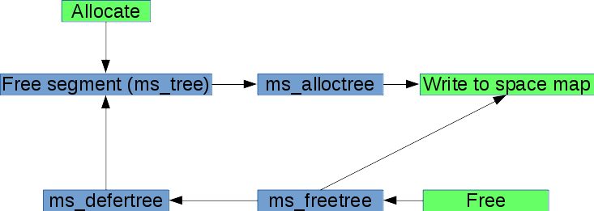

Figure 5. Операции с сегментами в метаслабе

Также в метаслабе присутствуют поля `ms_lbas` и `size_tree`. Они могут использоваться аллокаторами блоков (`metaslab block allocators`). `size_tree` содержит те же самые сегменты, что и `ms_tree`, только отсортированные не по границам сегментов, а по их размерам. Поле `ms_lbas` содержит адреса начала которые были получены в предыдущих аллокациях. Например, если необходимо выделить блока размером 512 байт (`align == 9`), будет выбран адрес `ms_lbas[9 - 1]` - 9-й элемент этого массива. В нём может находится адрес предыдущего выделенного блока размером 512 байт. Таким образом, аллокатор может помещать блоки одинакового размера рядом.

### Вес метаслаба

При аллокации места в пуле ZFS должна определить, в каком метаслабе нужно выделять блок/блоки. Для этого используется механизм весов: для каждого метаслаба в группе (физ. диске) определяется "вес", и этот вес учитывается при выборе метаслаба.

Рассмотрим основные параметры, по которым вычисляется вес:

- Удалено ли устройство?
- Количество свободного места.
- Количество свободного места и уровень фрагментированности метаслаба при установке параметра `metaslab_fragmentation_factor_enabled = 1`.
- Удалённость метаслаба от начала диска (`metaslab_lba_weighting_enabled = 1`).

Кроме того, при выборе метаслаба для `ditto`- или `log`-блоков учытывается расстояние между `DVA`. Выделяемые блоки должны быть либо на разных `vdev`-ах, либо в разных метаслабах, если нет возможности выделить их на разных устройствах.

### Методы выделения сегментов

Выбор метода выделения места в метаслабе зависит от двух факторов:

1. Каков максимальный размер свободного блока в метаслабе? Меньше ли он 16MB?
2. Каков процент свободного места в метаслабе? Меньше ли он 4%?

Если хотя бы на один из этих вопросов будет положительный ответ, то ZFS переходит от метода Dynamic block аллокатора к First-Fit аллокатору. Что, конечно же, сказывается на производительности.

## VDEV

TODO: здесь будет подробное описание VDEV-подсистемы. Немного о них можно почитать в разделе метки на vdev.

### Обобщённый интерфейс устройств VDEV

### Особенности VDEV типа disk

### Особенности VDEV типа raidz

## ARC

ARC (Adaptive Replacement Cache) - подсистема отвечающая за кеширование данных, проходящих между DMU и ZIO слоями.

Все запросы на запись/чтение проходят через эту подсистему. Исключение составляют лишь метки и l2cache - операции с ними проходят напрямую через подсистему `ZIO`.

Рассмотрим основные элементы классической [`"ARC: A Self-Tuning, Low Overhead Replacement Cache" by N. Megiddo & D. Modha, FAST 2003`] реализации `ARC`:

- MRU Cache (Most recently used) - кэш, в который попадают блоки в порядке требования их. Хранит данные.
- MFU Cache (Most frequently used) - кэш, в который попадают блоки, которые требуют чаще всего. Хранит данные.
- Ghost MRU - кэш, в котором содержатся блоки, "изгранные" (вытесненные) из MRU. Хранит указатели на блоки.
- Ghost MFU - кэш, в котором содержатся блоки, "изгранные" (вытесненные) из MFU. Хранит указатели на блоки.

Таки образом, ARC позволяет с одной стороны ускорить работу при последовательном чтении блоков (за счёт `MRU`), и ускорить работу при чтении случайных блоков (`MFU`) - с другой стороны.

Ghost-кэши используются для быстрого доступа к вытесненным из основного кэша данным. То есть, имея указатель на блок в этом кэше, мы можем относительно быстро считать данные, на которые этот блок указывает. Кроме того, при наличии кэша второго уровня (l2arc), представленного блочным устройством/устройствами с быстрым доступом (`SSD`), мы также можем получить ускорение чтения данных за счёт механизма Ghost-кэшей.

### Особенности arc

arc считается кэшем на чтение. Однако, он может влиять и на операции записи:

1. При записи невыровненных блоков необходимо прочитать "старые" данные.
2. При записи блоки добавляются в ARC.

### Особенности l2arc

В качестве кэша второго уровня обычно используют SSD-диски. Это позволяет ускорить чтение данных с пула.

К данным дискам предъявляются следующие требования/особенности:

- Высокая скорость чтения.
- Можно не беспокоиться об отказе устройства. Отказ устройства не повлияет на целостность данных пула.
- Скорость записи данных на устройство может быть низкой: запись происходит асинхронно, большими блоками по мере вытеснения данных из `RAM`.

### Особенности реализации ARC

Потребляемое ARC пространство (память) может быть разбито по типам элементов:

- ARC_SPACE_DATA
- ARC_SPACE_META
- ARC_SPACE_OTHER
- ARC_SPACE_HDRS
- ARC_SPACE_L2HDRS

При добавлении элементов этих типов увеличиваются соответствующие счётчики (`*_size*`), а также увеличивается счётчик `arcstat_meta_used` при добавлении элементов, которые не относятся к типу `ARC_SPACE_DATA`.

Сам ARC состоит из нескольких мультисписков, которые соответствуют указанным типам данных. На каждый тип приходится один мултилист, в котором, по умолчанию, `NCPUs`-подсписков.

## Журнал намерений (ZIL)

ZIL - подсистема, обеспечивающая сохранение "действий пользователя" (пользователя `ZFS`) в специальный лог. К этим событиям относятся такие действия, как запись данных в файл, изменение прав доступа, создание/удаление файлов/директорий и прочее.

В общем случае, действия с ZIL можно разбить на 2 этапа:

- добавление данных в ZIL (по аналогии с добавлением транзакций в транзакционную группу);
- коммит данных (по аналогии с синхронизацией транзакционных групп);

В некоторых случаях ZFS может решить хранить данные ZIL в выделенном устройстве - SLOG'е.

## Сбор статистики из kstat

Подсистема `kstat` предназначена для сбора различной статистики о `ZFS` и представления её пользователю.

`kstat` является частью `SPL` (`Solaris Porting Layer`) и адаптирована для `linux`.

Файлы `kstat` хранятся в директории `/proc/spl/kstat`.

Рассмотрим некоторые из них.

1. `/proc/spl/kstat/<pool>/dmu_tx_assign` Статистика (гистограмма) скорости добавления транзакций в группы. Позволяет оценить нагрузку на пул `ZFS`: чем больше транзакций присваивается с большей задержкой, тем нагрузка выше.

```
#cat /proc/spl/kstat/zfs/tank/dmu_tx_assign
451 1 0x01 32 1536 1451698481637227 1454383185424447
name                            type data
1 ns                            4    0
2 ns                            4    0
4 ns                            4    0
8 ns                            4    0
16 ns                           4    0
32 ns                           4    0
64 ns                           4    0
128 ns                          4    4195
256 ns                          4    1417
512 ns                          4    965
1024 ns                         4    74
2048 ns                         4    17
4096 ns                         4    0
8192 ns                         4    0
16384 ns                        4    9
32768 ns                        4    27
65536 ns                        4    432
131072 ns                       4    23578
262144 ns                       4    65034
524288 ns                       4    98741
1048576 ns                      4    2232869
2097152 ns                      4    410628
4194304 ns                      4    526712
8388608 ns                      4    1826
16777216 ns                     4    224
33554432 ns                     4    98
67108864 ns                     4    45
134217728 ns                    4    39
268435456 ns                    4    17
536870912 ns                    4    1
1073741824 ns                   4    0
2147483648 ns                   4    111
```

2. `/proc/spl/kstat/zfs/dbufs` "Сырая" статистика по DMU-буферам. Более "читабельную" версию можно получить с помощью скрипта `dbufstat.py`:

```
           pool  objset      object                        dtype  cached
          tank        0           0                 DMU_OT_DNODE     96K
          tank        0          31                 DMU_OT_BPOBJ     16K
          tank        0         105             DMU_OT_SPACE_MAP     16K
          tank       21           9   DMU_OT_PLAIN_FILE_CONTENTS     12G
          tank       21           8   DMU_OT_PLAIN_FILE_CONTENTS     12G
          tank       21           7   DMU_OT_PLAIN_FILE_CONTENTS     14G
          tank       21           0                 DMU_OT_DNODE    112K
```

3. `/proc/spl/kstat/<pool>/io` Статистика ввода вывода. Выводит информацию о том, сколько операций доступа и какое количество данных было проведено для пула. Стоит отмерить разницу в выводе `zpool list`, `zpool list -v` и `kstat/<pool>/io`.

`zpool list <pool>` выводит информацию о ZIO операциях с корневым `vdev`.

`zpool list -v <pool>` выводит детальную информацию о ZIO операциях по дочерним `vdev`.

`kstat/<pool>/io` выводит информацию по коневому `vdev`.

Кроме того, в данной статистике присутствуют следующие поля:

```c
hrtime_t   wtime;            /* cumulative wait (pre-service) time */
hrtime_t   wlentime;         /* cumulative wait length*time product*/
hrtime_t   wlastupdate;      /* last time wait queue changed */
hrtime_t   rtime;            /* cumulative run (service) time */
hrtime_t   rlentime;         /* cumulative run length*time product */
hrtime_t   rlastupdate;      /* last time run queue changed */
uint_t     wcnt;             /* count of elements in wait state */
uint_t     rcnt;             /* count of elements in run state */
```

Они связаны с длинной очереди входных данных на vdev'ы.

# Дополнительные материалы

В этом разделе представлены статьи и переводы, которые уже не актуальны, однако отражающие некоторые концепции `ZFS`.

## space maps

[By Jun-Hui Paul Duan on Jun 10, 2008](https://blogs.oracle.com/bonwick/entry/space_maps_russian)

Каждая файловая система должна следить за двумя основными вещами: где находятся данные, а где свободное пространство.

В принципе, отслеживание свободного пространства необязательно: каждый блок либо занят, либо свободен, поэтому свободное пространство может быть рассчитано как всё пространство за исключением занятого; а занятое пространство может быть обнаружено путем обхода всей файловой системы от корня. Блок, не найденный при обходе, свободен по определению.

На практике, поиск свободного пространства таким путём неприемлем, так как требует слишком много времени для любой файловой системы нетривиального размера. Чтобы сделать выделение и освобождение блоков быстрым, файловой системе нужен эффективный способ отслеживания свободного пространства. В этой заметке мы рассмотрим наиболее распространенные методы, присущие им проблемы масштабирования и новые подходы, разработанные для ZFS.

### Битовые карты

Наиболее распространенный способ представить свободное пространство - использовать битовую карту. Битовая карта - это просто битовый массив, в котором бит с номером N указывает, свободен ли блок с номером N. Накладные расходы на битовую карту невелики: 1 бит на блок. Для блока в 4Кб, это 1/(4096*8) = 0,003% от размера блока (здесь 8 - количество бит в байте).

Для файловой системы в 1Гб битовая карта займет 32Кб -- её можно держать в оперативной памяти и довольно быстро сканировать для поиска свободного пространства. Для файловой системы в 1Тб размер битовой карты составит уже 32 Мб -- такой объём ещё можно уместить в оперативной памяти, но это уже нетривиально в смысле размера и времени сканирования. Битовая карта для файловой системы в 1Пб потребует уже 32Гб, и уже просто-напросто не поместится в оперативной памяти большинства машин. Следовательно, сканирование битовой карты в этом случае потребует её чтения с диска, который намного медленнее оперативной памяти.

Ясно, что такой способ плохо масштабируется.

Очевидным выходом является разделение битовой карты на небольшие части и хранение количества битов, установленных в каждой из них. Например, для файловой системы в 1Пб с размером блока в 4Кб, свободное пространство может быть разделено на миллион битовых карт, размер каждой из которых составит 32Кб. Сводная информация -- миллион целых чисел, хранящих количество установленных битов в соответствующей битовой карте -- уже поместится в оперативной памяти, поэтому можно будет достаточно легко найти битовую карту со свободным местом и просканировать её для поиска места.

Но это не избавляет нас от одной фундаментальной проблемы: битовые карты нужно обновлять не только когда выделяется новый блок, но и тогда, когда блок освобождается. Файловая система может управлять локальностью выделяемых блоков (решать, в каком месте размещать новые данные), но не имеет никакого способа влиять на положение освобождаемых блоков. Простая команда вроде 'rm -rf' может вызвать освобождение блоков, разбросанных по всему диску. Например, удаление 4Гб данных (т.е. миллиона блоков по 4Кб) из нашей файловой системы размером в 1Пб потребует, в худшем случае, чтения, изменения и повторной записи миллиона битовых карт. Это означает два миллиона дисковых операций ввода/вывода для освобождения каких-то 4Гб -- что неразумно даже в худшем случае.

Этот фактор в большей степени, чем другие, является причиной плохой масштабируемости битовых карт: так как освобождение блоков часто происходит случайно, битовые карты, не помещающиеся в памяти, демонстрируют патологическую производительность при случайных последовательностях операций освобождения. Сбалансированные деревья

Другим распространенным способом представления свободного пространства является использование сбалансированного дерева диапазонов. Диапазон представляет собой непрерывный участок свободного пространства, описываемый двумя целыми числами: смещением и размером. Сортировка диапазонов в сбалансированном дереве по смещению позволяет эффективно реализовать поиск и выделение непрерывных кусков пространства. К сожалению, сбалансированные деревья диапазонов при работе со случайными последовательностями операций освобождения страдают от той же проблемы, что и битовые карты.

Что же делать?

### Отложенное освобождение

Один из способов уменьшить проблему случайного освобождения - это отложить обновление битовой карты или сбалансированного дерева, а вместо этого хранить список недавно освобождённых блоков. Когда этот список достигнет определенного размера, он может быть отсортирован в памяти и включён в нужное место битовой карты или дерева, возможно, с лучшей степенью локальности. Не идеально, но уже лучше.

А если пойти дальше?

### Карты пространства: списки диапазонов с журнальной структурой

Вспомним, что файловые системы с журнальной структурой уже ставили такой вопрос довольно давно: что, если вместо периодической свёртки журнала транзакций обратно в файловую систему, сделать сам журнал транзакций файловой системой?

Такой же вопрос можно поставить и по отношению к нашему списку отложенных операций: что, если вместо свёртки в битовую карту или дерево сделать сам список отложенных операций представлением свободного пространства?

Именно так и сделано в ZFS. Пространство каждого виртуального устройства в ZFS разделено на несколько сотен регионов, называемых метаслабы (metaslab). С каждым метаслабом связана карта пространства, которая описывает свободное пространство в метаслабе. Карта пространства (на диске) - это просто-напросто журнал операций выделения и освобождения блоков, упорядочненный по времени (точнее, номеру группы транзакций). Карты пространства делают случайные операции освобождения такими же эффективными, как и последовательные, потому что независимо от положения освобождаемого блока, на диске он представляется добавлением соответствующего диапазона (пары целых чисел - смещения и размера) к объекту "карта пространства" -- а добавление имеет идеальную локальность. Операции выделения блоков представляются на диске аналогично - добавлением диапазона к объекту "карта пространства" на диске с единственным отличием - установленным битом, показыващим, что это операция выделения, а не освобождения.

Когда ZFS принимает решение о выделении блоков из определенного метаслаба, она сперва читает карту пространства этого метаслаба с диска и применяет операции выделения и освобождения блоков к AVL-дереву свободных диапазонов в памяти, отсортированному по смещению. Это позволяет получить компактное представление свободного пространства этого метаслаба в памяти, которое обеспечивает эффективный поиск и выделение непрерывных кусков пространства. ZFS также использует представление в памяти как шанс сократить размер карты пространства на диске: если список на диске содержит большое количество взаимно уничтожающихся операций выделения/освобождения блоков, старый журнал на диске заменяется новым, содержащим меньшее количество диапазонов.

Карты пространства имеют несколько интересных свойств:

Не требуют инициализации: карта пространства без записей показывает, что операций выделения и освобождения блоков не было, все пространство доступно

Хорошо масштабируются: поскольку новые диапазоны только добавляются в конец объекта "карта пространства", для получения наилучшей производительности в памяти нужно хранить только лишь последний блок этого объекта, вне зависимости от того, пространством какого размера мы управляем

Не подвержены патологиям: карты пространства можно эффективно обновлять, независимо от последовательности операций выделения и освобождения

Одинаково эффективны при выделении свободного места, как при пустом, так и при заполненном пуле (в отличие от битовых карт, на сканирование которых требуется всё больше и больше времени по мере их наполнения) Помимо этого, нужно отметить, что когда свободное пространство, описываемое картой, полностью исчерпано, для ее представления достаточно одного диапазона. Поэтому карты пространства имеют прекрасное свойство: по мере приближения заполненности пула к 100%, карты пространств начинают буквально "испаряться", занимая всё меньше и меньше места, давая возможность максимально использовать имеющееся дисковое пространство для хранения полезной информации.